# Inferência Estatística II

2024-09-08

# Sumário

- Preliminares
- Revisão Sobre Estimação Pontual

# Preliminares

### Introdução à Inferência Estatística

A Inferência Estatística é um ramo da Estatística que se dedica a tirar conclusões sobre uma população com base em uma amostra representativa. Surgiu no início do século XX como uma resposta à necessidade de generalizar resultados de amostras, permitindo extrapolar informações de forma rigorosa e fundamentada.

### Pesquisadores Relevantes

Entre os principais pesquisadores, destacam-se: - **Ronald Fisher**, que desenvolveu a Teoria da Estimação e o Teste de Hipóteses. - **William Gosset (Student)**, que criou o teste t de Student. - **Harold Hotelling**, que desenvolveu a Teoria da Distribuição Multivariada.

#### Sugestão de Leitura

Uma Senhora Toma Chá: Como a Estatística Revolucionou a Ciência no Século XX.

### Ronald Fisher (1890-1962)

Ronald A. Fisher, estatístico britânico, desenvolveu a análise de variância (ANOVA) e o teste de significância.

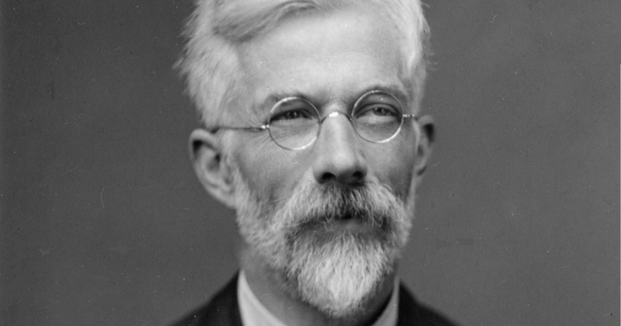

### Karl Pearson (1857-1936)

Karl Pearson, estatístico britânico, é conhecido por desenvolver o conceito de correlação e regressão.

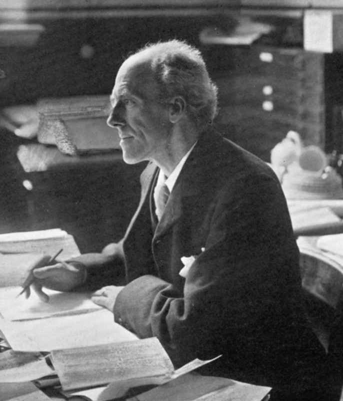

### Egon Pearson (1895-1980)

Egon Pearson, filho de Karl Pearson, é mais conhecido por suas contribuições à teoria dos testes de hipóteses.

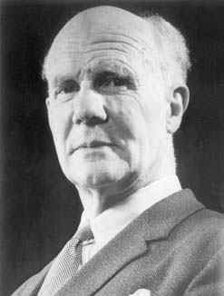

### Jerzy Neyman (1894-1981)

Jerzy Neyman, conhecido por suas contribuições à teoria estatística, desenvolveu os intervalos de confiança.

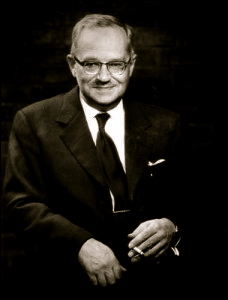

### William Gosset (1876-1937)

William Sealy Gosset, que trabalhou sob o pseudônimo “Student”, desenvolveu o teste t para pequenas amostras.

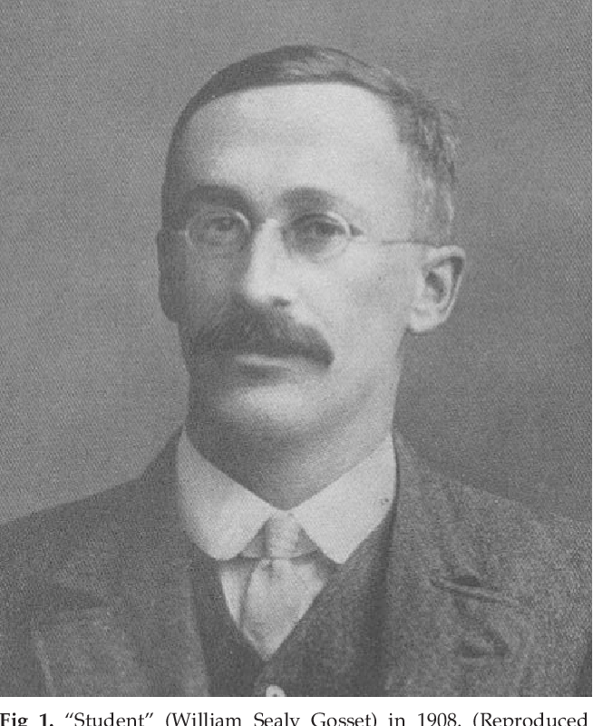

### Harold Hotelling (1895-1973)

Harold Hotelling foi um estatístico e economista americano, conhecido pelo teste de Hotelling para múltiplas variáveis.

[figure not shown]

# Contribuições para a Estatística

A Estatística é uma disciplina rica e diversificada, com uma longa história de contribuição de diversos pesquisadores notáveis. Além dos nomes frequentemente mencionados, muitos outros cientistas também desempenharam papéis cruciais no desenvolvimento da área. Cada um trouxe inovações e técnicas que ampliaram a capacidade da Estatística para interpretar dados e fazer previsões precisas.

O estudo aprofundado da inferência estatística é particularmente importante, pois é a base para muitas das técnicas utilizadas na análise de dados e na tomada de decisões informadas. A inferência estatística nos permite tirar conclusões sobre uma população com base em uma amostra, calcular intervalos de confiança e realizar testes de hipóteses para validar teorias.

Compreender esses métodos é essencial para aplicar a Estatística de maneira eficaz em diversos campos, desde a pesquisa científica até a análise de mercado e além. Portanto, um conhecimento sólido de inferência estatística é fundamental para qualquer profissional que deseje utilizar dados para gerar insights valiosos e tomar decisões fundamentadas.

# Revisão Sobre Estimação Pontual

Em um problema estatístico típico, temos uma variável aleatória $X$, mas sua função de densidade ou massa de probabilidade não é conhecida. A ignorância pode ser classificada em duas formas:

1 - $f(x)$ ou $p(x)$ é completamente desconhecida.

2 - A forma de $f(x)$ ou $p(x)$ é conhecida, mas um parâmetro $\theta$ é desconhecido.

Vamos focar na segunda classificação.

Alguns exemplos são os seguintes:

- $X$ tem uma distribuição exponencial, $Exp(\theta)$, onde $\theta$ é desconhecido.
- $X$ tem uma distribuição binomial $b(n, p)$, onde $n$ é conhecido, mas $p$ é desconhecido.
- $X$ tem uma distribuição gama $\Gamma(\alpha, \beta)$, onde tanto $\alpha$ quanto $\beta$ são desconhecidos.
- $X$ tem uma distribuição normal $N(\mu, \sigma^{2})$, onde tanto a média $\mu$ quanto a variância $\sigma^{2}$ de $X$ são desconhecidas.
- Se a variável $X$ segue uma distribuição normal com média $\mu$ desconhecida e variância $\sigma^2$ conhecida, a média amostral $\bar{X}$ é uma estimativa pontual para $\mu$.

# Função de Densidade e Parâmetros

Muitas vezes denotamos este problema dizendo que a variável aleatória $X$ tem uma função de densidade ou massa da forma $f(x; \theta)$ ou $p(x; \theta)$, onde $\theta \in \Omega$ para um conjunto especificado $\Omega$. Por exemplo, se $\Omega = \{\theta \mid \theta > 0\}$, então $\theta$ é um parâmetro positivo da distribuição. Queremos estimar $\theta$ com base em uma amostra.

### Observações da Amostra

As observações da amostra têm a mesma distribuição que $X$ e as denotamos como as variáveis aleatórias $X_1, X_2, \cdots, X_{n}$, onde $n$ denota o tamanho da amostra. Quando a amostra é realmente retirada, usamos letras minúsculas $x_1, x_2, ..., x_{n}$ como os valores ou realizações da amostra. Muitas vezes, assumimos que as observações da amostra $X_1, X_2, ..., X_{n}$ também são mutuamente independentes, caso em que chamamos a amostra de amostra aleatória.

# Definições de Amostra e Estatística

**Definição 1:** Se as variáveis aleatórias $X_1, X_2, \dots, X_{n}$ são independentes e identicamente distribuídas (iid), então essas variáveis constituem uma amostra aleatória de tamanho $n$ da distribuição comum.

**Definição 2:** Seja $X_1, X_2, \dots, X_{n}$ uma amostra de uma variável aleatória $X$. Seja $T = T(X_1, X_2, \dots, X_{n})$ uma função da amostra. Então $T$ é chamado de Estatística. Uma vez que a amostra é retirada, então $t$ é chamado de realização de $T$, onde $t = T(x_1, x_2, \dots, x_{n})$ e $x_1, x_2, \dots, x_{n}$ são as realizações da amostra.

### Exemplos

Alguns exemplos são os seguintes:

- A média amostral $\bar{X} = \frac{1}{n}\sum_{i=1}^n X_i$ é uma estatística que estima a média populacional.
- A variância amostral é uma função dos dados da amostra que estima a variância populacional.

# Estimadores Pontuais

### Estimadores Não Viesados

Sejam $X_{1},X_{2},...,X_{n}$ uma amostra aleatória de uma variável aleatória $X$ com uma função de densidade ou massa da forma $f(x;\theta)$ ou $p(x;\theta)$, onde $\theta \in \Omega$ para um conjunto especificado $\Omega$. Nessa situação, faz sentido considerar uma estatística $T$, como um estimador de $\theta$. Mais formalmente, $T$ é chamado de estimador pontual de $\theta$. Embora chamemos $T$ de estimador de $\theta$, chamamos sua realização $t$ de estimativa de $\theta$.

Observem que para ser um estimador pontual basta ser uma Estatística. Não fazemos nenhuma menção a qualquer correspondência entre o estimador e o parâmetro a ser estimado. No entanto, existem várias propriedades dos estimadores pontuais que discutiremos e algumas técnicas úteis que ajudam a encontrar os melhores candidatos, tais como Viés, Consistência, Eficiência, entre outras.

### Observações

- Se $E(T)\neq \theta,$ dizemos que $T$ é um estimador viesado de $\theta$.
- Se ${\displaystyle \lim_{n\rightarrow \infty}E(T)=\theta},$ dizemos que $T$ é um estimador assintoticamente não viesado para $\theta$.

### Exemplos

Considere uma amostra aleatória de uma distribuição com média $\mu$ e variância $\sigma^{2}<\infty.$

- $\bar{X}_{n}=\dfrac{\Sumi X_{i}}{n}$ é um estimador não viesado para $\mu$;
- Além disso, $Var\left(\bar{X}_{n}\right)=\dfrac{\sigma^{2}}{n}\overset{n\rightarrow\infty}{\rightarrow}0$;
- $S^{2}=\dfrac{1}{n-1}\Sumi(X_{i}-\bar{X}_{n})^{2}$ é um estimador não viesado para $\sigma^{2}$;

Vejam alguns exemplos práticos, [cliquem aqui!](https://est711.shinyapps.io/EstimadoresViesados/)

# Exemplos

Considere $X_{i}\Sim U(0,\theta),i=1,\cdots,n.$ Seja $Y_{n}=max(X_{1},\cdots,X_{n}).$
$$\begin{align*}
F_{Y_{n}}(y)&=P(Y_{n}\leq y)=P(max(X_{1},\cdots,X_{n})\leq y)\\
&=P(X_{1}\leq y,X_{2}\leq y,\cdots, X_{n}\leq y)\\
&=\Prodi P(X_{i}\leq y)=\left[P(X_{1}\leq y)\right]^{n}\\
&=\left(\dfrac{y}{\theta}\right)^{n},~\text{para}~y\in
(0,\theta).
\end{align*}$$

# Exemplos

Logo, a função densidade de $Y_{n}$ é
$$\begin{align*}
f_{Y_{n}(y)}=\dfrac{dF_{Y_{n}}(y)}{dy}=\dfrac{ny^{n-1}}{\theta^{n}}.
\end{align*}$$
Segue que,
$$\begin{align*}
E(Y_{n})&=\int_{0}^{\theta}yf(y)dy=\dfrac{n}{\theta^{n}}\int_{0}^{\theta}y^{n}dy=\dfrac{n}{n+1}\theta
\end{align*}$$

Logo,

- $Y_{n}$ é um estimador viesado para $\theta;$
- Note que $Y_{n}$ é assintoticamente não viesado para $\theta$ e que $\dfrac{n+1}{n}Y_{n}$ é um estimador não viesado para $\theta$.

# Convergência em Probabilidade

Dizemos que uma sequência de variáveis aleatórias $\{X_{n}\}_{n\geq 1}$ converge para uma variável aleatória $X$ se, para todo $\varepsilon > 0,$

$$\lim_{n\to\infty}P(|X_{n} - X| \geq \varepsilon) = 0,$$

ou equivalentemente,

$$\lim_{n\to\infty}P(|X_{n} - X| < \varepsilon) = 1.$$

Se isso ocorrer, escrevemos $X_{n} \xrightarrow{P} X$.

Em muitas situações, $X$ é uma v.a. degenerada, ou seja, $X$ é igual a uma constante com probabilidade $1.$ Vejam alguns exemplos, [Clique aqui!](https://est711.shinyapps.io/ConvergenciaProbabilidade/).

### Exemplo

Suponha que $X_n$ seja a média amostral de uma sequência de $n$ lançamentos de uma moeda com probabilidade $p$ de sair cara. Ou seja, para cada $n$, $X_n$ é a fração de caras obtidas após $n$ lançamentos.

Por exemplo:

- Para $n = 1$, $X_1$ será $1$ se o primeiro lançamento for cara, ou $0$ se for coroa.
- Para $n = 10$, $X_{10}$ será a fração de caras obtidas em $10$ lançamentos.
- Para $n = 100$, $X_{100}$ será a fração de caras obtidas em $100$ lançamentos, e assim por diante.

Agora, suponha que a moeda seja justa, ou seja, $p = 0.5$. À medida que $n$ aumenta, esperamos que a média $X_n$ dos resultados dos lançamentos (fração de caras) se aproxime de $p = 0.5$, que é o valor esperado da proporção de caras.

Neste caso:

- $X_n$ é a fração de caras nos $n$ lançamentos (a variável aleatória dependente de $n$).
- $X$ é o valor esperado $p = 0.5$, que é o valor ao qual $X_n$ converge.

Conforme aumentamos o número de lançamentos $n$, a probabilidade de que a média $X_n$ esteja muito distante de $0.5$ (ou seja, $|X_n - 0.5| \geq \varepsilon$ para um $\varepsilon > 0$) diminui. Isso exemplifica que $X_n$ converge em probabilidade para $X = 0.5$.

Ou seja:

$$X_n \xrightarrow{P} 0.5 \quad \text{quando} \quad n \to \infty.$$

Neste exemplo, $X_n$ representa a fração de caras nos $n$ lançamentos e $X$ é o valor fixo $0.5$, que é o valor esperado a longo prazo.

# Desigualdades de Markov e Tchebychev

**Desigualdade de Markov:** A Desigualdade de Markov afirma que, para uma variável aleatória não negativa $Y$ e um valor positivo $a$, temos:

$$P(Y \geq a) \leq \frac{\mathbb{E}[Y]}{a}.$$

**Desigualdade de Tchebychev:** Seja $X$ uma v.a. com média $\mu$ e variância $\sigma^{2}.$ Então,

$$P(|X-\mu|\geq t)\leq
\dfrac{Var(X)}{t^{2}}=\dfrac{\sigma^{2}}{t^{2}},~t>0$$

O nome correto é Tchebychev no contexto de português, enquanto Chebyshev é a forma utilizada em inglês. Ambos se referem ao mesmo matemático russo, Pafnuty Chebyshev.

# Lei Fraca dos Grandes Números

Seja $\{X_{n}\}_{n\geq 1}$ uma sequência de v.a. i.i.d, com média $\mu$ e variância $\sigma^{2}<\infty.$ Então,

$$\bar{X}_{n}=\dfrac{\sum_{i=1}^{n} X_{i}}{n}\xrightarrow{P} \mu$$

Vejam alguns exemplos práticos, [Clique aqui!](https://est711.shinyapps.io/ConvergenciaProbabilidade/).

Seja $\varepsilon>0.$ Temos que,

$$P(|\bar{X}_{n}-\mu|\geq \varepsilon)=P(|\bar{X}_{n}-\mu|\geq
\varepsilon) \underset{\mathclap{\substack{\xuparrow \\
\text{Tchebychev}}}}{\leq}\dfrac{1}{\varepsilon^{2}}
\dfrac{\sigma^{2}}{n} \xrightarrow[n\rightarrow\infty]{} 0$$

# Propriedade da Convergência em Probabilidade

Suponha que $X_{n}\xrightarrow{P} X$ e $Y_{n}\xrightarrow{P} Y.$ Então, $X_{n}+Y_{n}\xrightarrow{P} X+Y.$

# Propriedades de Convergência em Probabilidades

### Teorema

Suponha que $X_{n}$ converge em probabilidade para $X$ e $a$ é uma constante. Então, $aX_{n}$ converge em probabilidade para $aX$.

### Demonstração

Se $a = 0$, o resultado é imediato. Suponha $a \neq 0$. Seja $\varepsilon > 0$. O resultado segue das seguintes igualdades:

$P[|aX_{n} - aX| \geq \varepsilon] = P[|a||X_{n} - X| \geq \varepsilon] = P[|X_{n} - X| \geq \varepsilon/|a|]$

E pelas hipóteses, o último termo converge para $0$ conforme $n \to \infty$.

### Teorema

Suponha que $X_{n}$ converge em probabilidade para $a$ e a função real $g$ é contínua em $a$. Então, $g(X_{n})$ converge em probabilidade para $g(a)$.

### Demonstração

Seja $\varepsilon > 0$. Como $g$ é contínua em $a$, existe $\delta > 0$ tal que se $|x - a| < \delta$, então $|g(x) - g(a)| < \varepsilon$. Assim,

$|g(x) - g(a)| \geq \varepsilon \Rightarrow |x - a| \geq \delta$

Substituindo $X_{n}$ por $x$ na implicação acima, obtemos

$P[|g(X_{n}) - g(a)| \geq \varepsilon] \leq P[|X_{n} - a| \geq \delta]$

Pelas hipóteses, o último termo converge para $0$ conforme $n \to \infty$, o que nos dá o resultado.

### Propriedades Adicionais

Este teorema nos fornece muitos resultados úteis. Por exemplo, se $X_{n}$ converge em probabilidade para $a$, então:

- $X^{2}_{n}$ converge em probabilidade para $a^{2}$.
- $\frac{1}{X_{n}}$ converge em probabilidade para $\frac{1}{a}$, desde que $a \neq 0$.
- $X_{n}$ converge em probabilidade para $\sqrt{a}$, desde que $a \geq 0$.

### Teorema

Se $X_{n}$ converge em probabilidade para $X$ e $g$ é uma função contínua, então $g(X_{n})$ converge em probabilidade para $g(X)$.

### Demonstração

Página 104 de Tucker (1967).

### Teorema

Suponha que $X_{n}$ converge em probabilidade para $X$ e $Y_{n}$ converge em probabilidade para $Y$. Então, $X_{n}Y_{n}$ converge em probabilidade para $XY$.

### Demonstração

Utilizando os resultados anteriores, temos:

$$\begin{align*}
X_{n}Y_{n} &= \frac{1}{2}X^{2}_{n} + \frac{1}{2}Y^{2}_{n} -
\frac{1}{2}(X_{n} - Y_{n})^{2} \xrightarrow{P} \frac{1}{2}X^2 +
\frac{1}{2}Y^2 - \frac{1}{2}(X - Y)^{2}\\
&= XY
\end{align*}$$